# Reproducible Research: Peer Assessment 1

### author “Jizong Liang”

date: 2015-05-15

### Loading and preprocessing the data

##### 1. Load the data (i.e. read.csv())

```r
if(!file.exists("./data")){dir.create("./data")}
fileUrl <- "https://d396qusza40orc.cloudfront.net/repdata%2Fdata%2Factivity.zip"
download.file(fileUrl,destfile="./data/Dataset.zip",method="curl")

## Unzip the file folder downloaded into the "data" folder.
unzip(zipfile="./data/Dataset.zip",exdir="./data")

ActivityData <- read.csv("./data/activity.csv")
```

### What is mean total number of steps taken per day?

```r
stepsByDay <- tapply(ActivityData$steps, ActivityData$date, sum, na.rm=TRUE)
```

##### 1. Make a histogram of the total number of steps taken each day

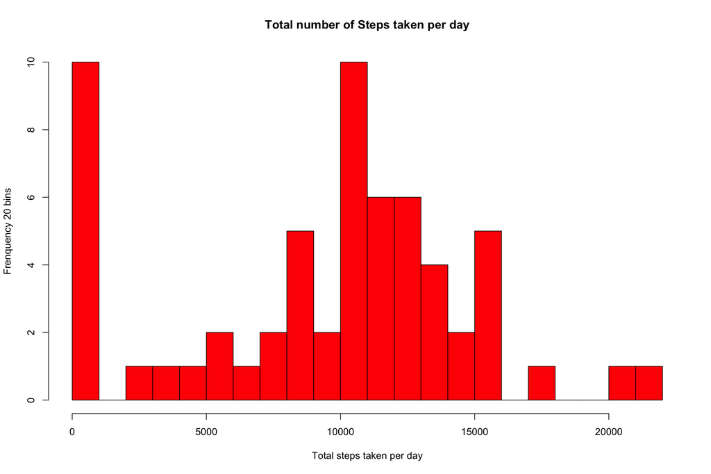

```r
(hist(stepsByDay,breaks=20,col="red", xlab="Total steps taken per day",
     ylab="Frenquency 20 bins",main="Total number of Steps taken per day"))
```

##### 2. Calculate and report the mean and median total number of steps taken per day

```r
stepsByDayMean=mean(stepsByDay)
stepsByDayMedian=median(stepsByDay)
```

- Mean: 9354.2295082
- Median: 10395

### What is the average daily activity pattern?

```r
(AveDailyActivityPattern <- aggregate(ActivityData$steps,
                                       list(ActivityData$interval), mean, na.rm=TRUE))
colnames(AveDailyActivityPattern)=c("Interval","meanSteps")
## see reference item 1 for further detail about aggregate()
```

##### 1. Make a time series plot

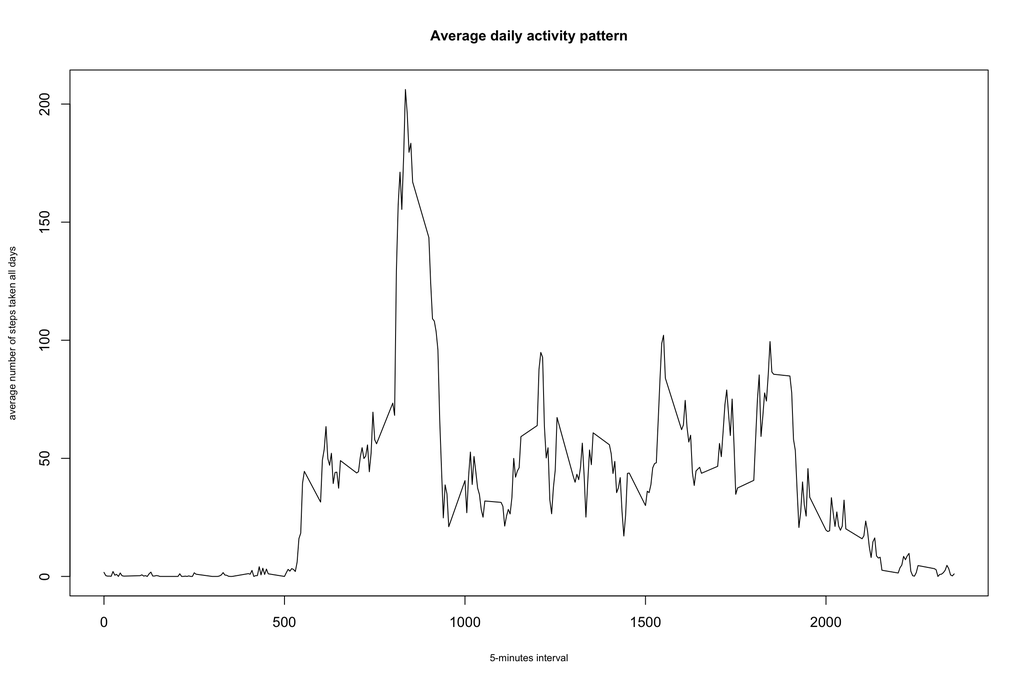

```r
(plot(AveDailyActivityPattern,type="l",xlab="5-minutes interval",
      ylab="average number of steps taken all days",
      main="Average daily activity pattern",cex.lab=0.7,cex.main=1))
```

##### 2. Which 5-minute interval, on average across all the days in the dataset, contains the maximum number of steps?

```r
mostSteps <- which.max(AveDailyActivityPattern$meanSteps)
x=AveDailyActivityPattern$Interval[mostSteps]
time <- substr(as.POSIXct(sprintf("%04.0f", x), format='%H%M'), 12, 16)
```

- Most Steps at: 08:35

### Imputing missing values

##### 1. Calculate and report the total number of missing values in the dataset

```r
TotalNumMissingValues <- length(which(is.na(ActivityData$steps)))
```

- Number of missing values: 2304

##### 2. Devise a strategy for filling in all of the missing values in the dataset.

##### 3. Create a new dataset that is equal to the original dataset but with the missing data filled in.

```r
Imputed <- ActivityData
Imputed$steps <- impute(ActivityData$steps, mean)
result <- length(which(is.na(Imputed$steps)))
```

- Number of missing values 0

##### 4. Make a histogram of the total number of steps taken each day

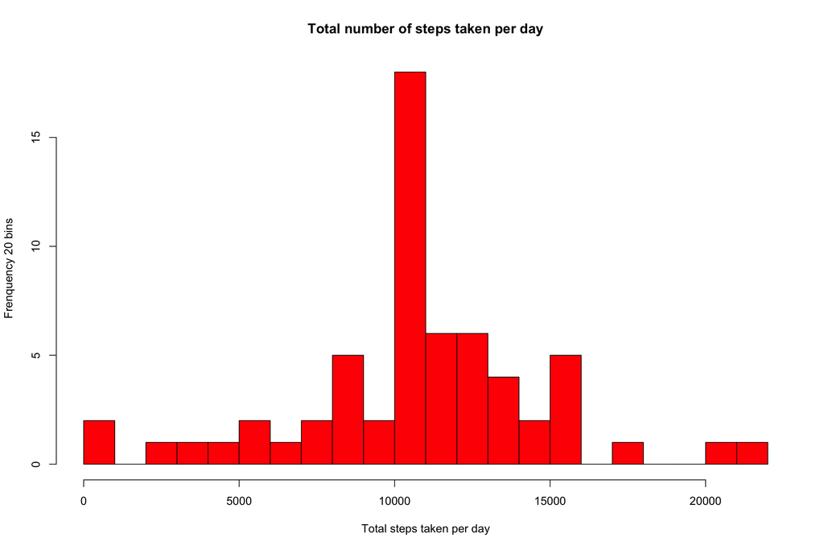

```r
stepsByDay2 <- tapply(Imputed$steps, Imputed$date, sum, na.rm=TRUE)
hist(stepsByDay2, breaks=20, col="red",xlab="Total steps taken per day",
     ylab="Frenquency 20 bins", main="Total number of steps taken per day")
```

```r
a=mean(stepsByDay2)
b=median(stepsByDay2)
```

### Are there differences in activity patterns between weekdays and weekends?

##### 1. Create a new factor variable in the dataset with two levels – “weekday” and “weekend” indicating whether a given date is a weekday or weekend day.

```r
Imputed$dateType <-  ifelse(as.POSIXlt(Imputed$date)$wday %in% c(0,6), 'weekend', 'weekday')
## see Reference item 3 for further detail about date and time.
```

##### 2. Make a panel plot containing a time series plot

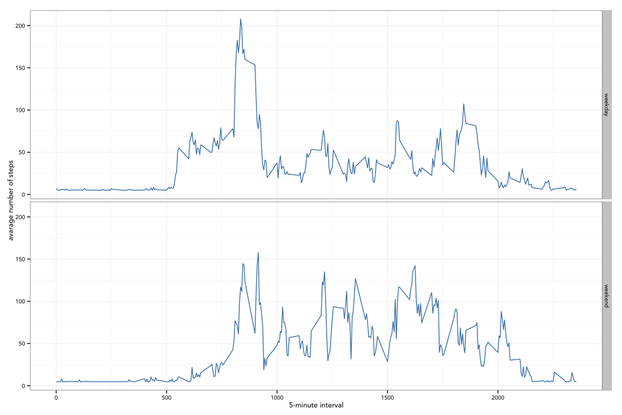

```r
averagedImputed <- aggregate(steps ~ interval + dateType, data=Imputed, mean)
ggplot(averagedImputed, aes(interval, steps)) +
    geom_line(col="steelblue") +
    facet_grid(dateType ~ .) +
    xlab("5-minute interval") +
    ylab("avarage number of steps")+
    theme_bw(base_family = "Avenir", base_size = 10)
```

**Reference**

1:Using aggregate and apply in R, 05-22-2013 http://davetang.org/muse/2013/05/22/using-aggregate-and-apply-in-r/

2: Scientific notation in knitr: How to improve typography http://stackoverflow.com/questions/26437835/scientific-notation-in-knitr-how-to-improve-typography

3: Handling date-times in R,Cole Beck, 08-30-2012 http://biostat.mc.vanderbilt.edu/wiki/pub/Main/ColeBeck/datestimes.pdf